# HW 3 Nonlinear & Nonparametric Regression: Data Analysis Problems

Advanced Regression (STAT 353-0)

Author

Chan Lee

Published

February 16, 2025

**Github Repo Link**

To link to your github **repo**sitory, appropriately edit the example link below. Meaning replace `https://your-github-repo-url` with your github repo url. Suggest verifying the link works before submitting.

https://github.com/stat-353-0-2025-winter/hw-3-nonlinear-chanlee0716.git

## Load packages & data

```r
# load package(s)
library(stats)
library(MASS)
library(effects)
library(car)
library(ggplot2)
library(plotly)
library(mgcv)

# load data
ginzberg_data <- read.table("data/Ginzberg.txt", header = TRUE, sep = "", stringsAsFactors = TRUE) # read in Ginzberg data
states_data <- read.table("data/states.txt", header = TRUE, sep = "", stringsAsFactors = TRUE) # read in states data
duncan_data <- read.table("data/Duncan.txt", header = TRUE, sep = "", stringsAsFactors = TRUE) # read in duncan data
chile_data <- read.table("data/chile.txt", header = TRUE, sep = "", stringsAsFactors = TRUE) # read in chile data
chile_data <- subset(chile_data, vote %in% c("Y", "N")) # only focus on observations with vote = Y or N

# Convert 'vote' to numeric (1 = Yes, 0 = No)
chile_data$vote <- ifelse(chile_data$vote == "Y", 1, 0)

# Convert categorical variables to factors
chile_data$sex <- as.factor(chile_data$sex)
chile_data$region <- as.factor(chile_data$region)
chile_data$education <- as.factor(chile_data$education)
```

## Data analysis problems

### 1. Exercise D17.1

The data in `Ginzberg.txt` (collected by Ginzberg) were analyzed by Monette (1990). The data are for a group of 82 psychiatric patients hospitalized for depression. The response variable in the data set is the patient’s score on the Beck scale, a widely used measure of depression. The explanatory variables are “simplicity” (measuring the degree to which the patient “sees the world in black and white”) and “fatalism”. (These three variables have been adjusted for other explanatory variables that can influence depression.) Use the adjusted scores for the analysis.

Using the full quadratic regression model

$$Y = \beta_0 + \beta_1 X_1 + \beta_2 X_2 + \beta_3 X_1^2 + \beta_4 X_2^2 + \beta_5 X_1 X_2 + \epsilon$$

regress the Beck-scale scores on simplicity and fatalism.

```r
# Fit full quadratic model
ginzberg_model_full <- lm(adjdepression ~ adjsimplicity + adjfatalism + I(adjsimplicity^2) + I(adjfatalism^2) + I(adjsimplicity * adjfatalism), data = ginzberg_data)

# Print model summary
summary(ginzberg_model_full)
```

```
Call:
lm(formula = adjdepression ~ adjsimplicity + adjfatalism + I(adjsimplicity^2) +
    I(adjfatalism^2) + I(adjsimplicity * adjfatalism), data = ginzberg_data)

Residuals:
     Min       1Q   Median       3Q      Max
-0.63090 -0.23619 -0.06667  0.21295  1.04481

Coefficients:
                               Estimate Std. Error t value Pr(>|t|)
(Intercept)                    -0.10865    0.20687  -0.525   0.6010
adjsimplicity                   0.82039    0.29702   2.762   0.0072 **
adjfatalism                     0.55247    0.28391   1.946   0.0554 .
I(adjsimplicity^2)              0.08172    0.15374   0.532   0.5966
I(adjfatalism^2)                0.20927    0.18663   1.121   0.2657
I(adjsimplicity * adjfatalism) -0.55366    0.27855  -1.988   0.0505 .
---
Signif. codes:  0 '***' 0.001 '**' 0.01 '*' 0.05 '.' 0.1 ' ' 1

Residual standard error: 0.3738 on 76 degrees of freedom
Multiple R-squared:  0.4755,    Adjusted R-squared:  0.441
F-statistic: 13.78 on 5 and 76 DF,  p-value: 1.416e-09
```

1. Are the quadratic and product terms needed here?

**Solution**

As seen from the full quadratic model above, the quadratic terms have very high p-values, making us believe that they are not that significant. Thus, we removed them below, and the linear variables and the product term all have low p-values. Thus, we kept them.

```r
# Fit full quadratic model
ginzberg_model <- lm(adjdepression ~ adjsimplicity + adjfatalism + I(adjsimplicity * adjfatalism), data = ginzberg_data)

# Print model summary
summary(ginzberg_model)
```

```
Call:
lm(formula = adjdepression ~ adjsimplicity + adjfatalism + I(adjsimplicity *
    adjfatalism), data = ginzberg_data)

Residuals:
     Min       1Q   Median       3Q      Max
-0.58251 -0.23705 -0.05099  0.17981  1.21560

Coefficients:
                               Estimate Std. Error t value Pr(>|t|)
(Intercept)                     -0.1366     0.2023  -0.676 0.501319
adjsimplicity                    0.7736     0.2083   3.714 0.000381 ***
adjfatalism                      0.7218     0.1811   3.987 0.000150 ***
I(adjsimplicity * adjfatalism)  -0.3168     0.1430  -2.216 0.029607 *
---
Signif. codes:  0 '***' 0.001 '**' 0.01 '*' 0.05 '.' 0.1 ' ' 1

Residual standard error: 0.3721 on 78 degrees of freedom
Multiple R-squared:  0.4668,    Adjusted R-squared:  0.4463
F-statistic: 22.76 on 3 and 78 DF,  p-value: 1.103e-10
```

2. Graph the data and the fitted regression surface in three dimensions. Do you see any problems with the data?

**Solution**

As seen in the 3d plot below, we can see that adjusted depression increases as adjusted simplicity increases and adjusted fatalism decreases. Also, adjusted depression decreases as both adjusted simplicity and adjfatatalism decrease.

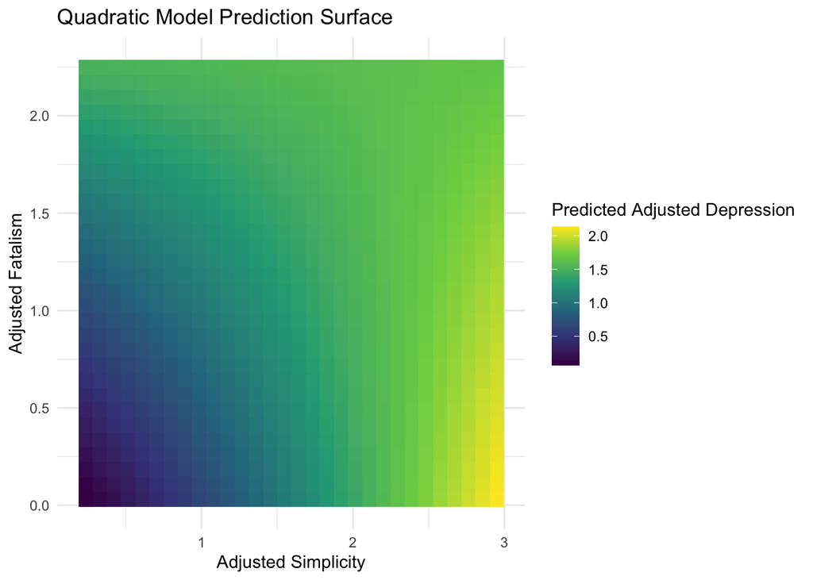

```r
# Create a grid of adjsimplicity and adjfatalism values
simplicity_seq <- seq(min(ginzberg_data$adjsimplicity, na.rm = TRUE),
                      max(ginzberg_data$adjsimplicity, na.rm = TRUE),
                      length.out = 30)

fatalism_seq <- seq(min(ginzberg_data$adjfatalism, na.rm = TRUE),
                    max(ginzberg_data$adjfatalism, na.rm = TRUE),
                    length.out = 30)

grid <- expand.grid(adjsimplicity = simplicity_seq, adjfatalism = fatalism_seq)

# Predict adjdepression for each grid point
grid$predicted_adjdepression <- predict(ginzberg_model, newdata = grid)

ggplot(grid, aes(x = adjsimplicity, y = adjfatalism, fill = predicted_adjdepression)) +
  geom_tile() +
  scale_fill_viridis_c() +
  labs(title = "Quadratic Model Prediction Surface",
       x = "Adjusted Simplicity",
       y = "Adjusted Fatalism",
       fill = "Predicted Adjusted Depression") +
  theme_minimal()
```

```r
outlierTest(ginzberg_model)
```

```
   rstudent unadjusted p-value Bonferroni p
71 3.710466         0.00038878      0.03188
```

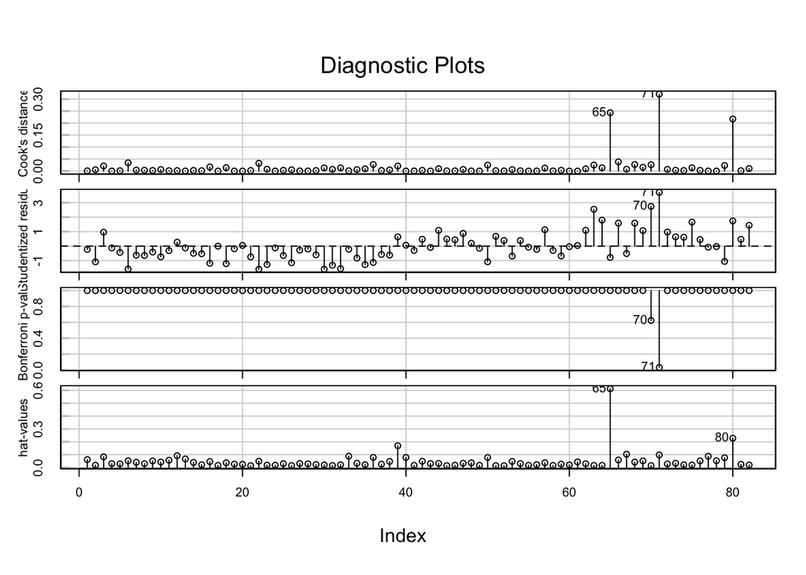

```r
influenceIndexPlot(ginzberg_model)
```

### 2. Exercise D18.2

For this analysis, use the `States.txt` data, which includes average SAT scores for each state as the outcome.

1. Put together a model with SAT math (`satMath`) as the outcome and `region`, `population`, `percentTaking`, and `teacherPay` as the explanatory variables, each included as linear terms. Interpret the findings.

**Solution**

I took out teacherPay and population, as they were insignificant. Furthermore, the majority of interactions seemed to be insignificant, so I removed them all as well. Our new model has high explanatory power, with an $R^2$ value of 0.882, meaning approximately 88.2% of the variance in SAT Math scores is explained by the predictors. From our model, we find that the percent of high-school seniors taking the SAT exam is a very strong predictor of SAT Math scores, with a tiny p value.

```r
states_model_full <- lm(satMath ~ region + population + percentTaking + teacherPay, data = states_data)

states_model <- lm(satMath ~ region + percentTaking , data = states_data)

summary(states_model)
```

```
Call:
lm(formula = satMath ~ region + percentTaking, data = states_data)

Residuals:
     Min       1Q   Median       3Q      Max
-23.8437  -7.8976   0.9555   9.1222  24.2887

Coefficients:
              Estimate Std. Error t value Pr(>|t|)
(Intercept)   575.3195     7.1129  80.883  < 2e-16 ***
regionESC     -12.4364     9.1606  -1.358   0.1820
regionMA       -0.9210    12.7733  -0.072   0.9429
regionMTN     -15.5533     7.5625  -2.057   0.0461 *
regionNE        4.0235    11.7888   0.341   0.7346
regionPAC      -8.6805     9.4824  -0.915   0.3653
regionSA      -27.3429     9.2160  -2.967   0.0050 **
regionWNC      13.3089     8.1932   1.624   0.1120
regionWSC     -17.1366     8.9081  -1.924   0.0614 .
percentTaking  -1.0666     0.1736  -6.144  2.7e-07 ***
---
Signif. codes:  0 '***' 0.001 '**' 0.01 '*' 0.05 '.' 0.1 ' ' 1

Residual standard error: 13.21 on 41 degrees of freedom
Multiple R-squared:  0.882, Adjusted R-squared:  0.8561
F-statistic: 34.05 on 9 and 41 DF,  p-value: 2.989e-16
```

2. Now, instead approach building this model using the nonparametric-regression methods discussed in Chapter 18 of our main course textbook, FOX. Fit a general nonparametric regression model *and* an additive-regression model, comparing the results to each other and to the linear least-squares fit to the data (in part (a))). If you have problems with categorical variables for the nonparametric models, feel free to remove them. Be sure to explain the models.

**Solution**

```r
# General nonparametric regression using loess()
loess_fit <- loess(satMath ~ population + percentTaking + teacherPay,
                   data = states_data, span = 0.6)
loess_pred <- predict(loess_fit, newdata = states_data)

# Additive regression model using gam() from the mgcv package (remove population)
gam_fit <- gam(satMath ~ s(percentTaking) + region, data = states_data)
#summary(gam_fit)
gam_pred <- predict(gam_fit, newdata = states_data)

# Compare the models by computing mean squared error (MSE) on the observed data:
lm_mse    <- mean(residuals(states_model)^2)
loess_mse <- mean((states_data$satMath - loess_pred)^2)
gam_mse   <- mean((states_data$satMath - gam_pred)^2)

cat("Linear Model MSE:", lm_mse, "\n")
```

```
Linear Model MSE: 140.3929
```

```r
cat("General Nonparametric (loess) MSE:", loess_mse, "\n")
```

```
General Nonparametric (loess) MSE: 103.1622
```

```r
cat("Additive Model (gam) MSE:", gam_mse, "\n")
```

```
Additive Model (gam) MSE: 94.951
```

```r
# Optionally, one can visualize the fitted values.
# For example, create a data frame comparing observed and fitted values:
#df_compare <- data.frame(
#  satMath    = states_data$satMath,
#  lm_fit     = lm_fit$fitted.values,
#  loess_fit  = loess_pred,
#  gam_fit    = gam_pred
#)

# A simple base R plot comparing observed vs. fitted for each model:
#plot(df_compare$satMath, df_compare$lm_fit, pch = 16, col = "red",
#     xlab = "Observed SAT Math", ylab = "Fitted SAT Math",
#     main = "Observed vs. Fitted Values")
#points(df_compare$satMath, df_compare$loess_fit, pch = 17, col = "blue")
#points(df_compare$satMath, df_compare$gam_fit, pch = 18, col = "green")
#abline(0,1, lty = 2)  # 45-degree line for reference
#legend("topleft", legend = c("Linear", "Loess", "Additive (gam)"),
#       col = c("red", "blue", "green"), pch = c(16,17,18))
```

3. Can you handle the nonlinearity by a transformation or by another parametric regression model, such as a polynomial regression? Investigate and explain. What are the tradeoffs between these nonparametric and parametric approaches?

**Solution**

```r
# Assume states_data is already read in and region is a factor.
states_data$region <- as.factor(states_data$region)

# Fit a cubic polynomial regression model.
# Here we model SAT math scores as a function of cubic polynomial functions of percentTaking and teacherPay,
# along with the categorical variable region.
poly_fit <- lm(satMath ~ poly(percentTaking, 3) + region, data = states_data)
summary(poly_fit)
```

```
Call:
lm(formula = satMath ~ poly(percentTaking, 3) + region, data = states_data)

Residuals:
    Min      1Q  Median      3Q     Max
-22.314  -7.423  -1.308   7.660  18.230

Coefficients:
                        Estimate Std. Error t value Pr(>|t|)
(Intercept)              543.358      5.536  98.146  < 2e-16 ***
poly(percentTaking, 3)1 -159.628     28.920  -5.520  2.4e-06 ***
poly(percentTaking, 3)2   77.444     18.512   4.183 0.000158 ***
poly(percentTaking, 3)3   -1.190     13.546  -0.088 0.930424
regionESC                -17.097      7.864  -2.174 0.035818 *
regionMA                 -24.180     12.140  -1.992 0.053437 .
regionMTN                -12.065      6.500  -1.856 0.071010 .
regionNE                 -22.931     11.983  -1.914 0.063021 .
regionPAC                 -2.572      8.357  -0.308 0.759867
regionSA                 -32.136      8.020  -4.007 0.000268 ***
regionWNC                  5.867      7.297   0.804 0.426283
regionWSC                -20.555      7.705  -2.668 0.011061 *
---
Signif. codes:  0 '***' 0.001 '**' 0.01 '*' 0.05 '.' 0.1 ' ' 1

Residual standard error: 11.2 on 39 degrees of freedom
Multiple R-squared:  0.9194,    Adjusted R-squared:  0.8967
F-statistic: 40.44 on 11 and 39 DF,  p-value: < 2.2e-16
```

```r
# Get predictions at the observed data points
poly_pred <- predict(poly_fit, newdata = states_data)

# Compute the Mean Squared Error (MSE)
poly_mse <- mean((states_data$satMath - poly_pred)^2)
cat("Polynomial Regression (cubic) MSE:", poly_mse, "\n")
```

```
Polynomial Regression (cubic) MSE: 95.90071
```